# Understanding Ford GoBike Users

## by Yi Le POH

## Investigation Overview

In this investigation, we want to understand our customer demographics in Ford GoBike, and our customer behaviour.

We want to identify customer characteristics with their associated behaviour. With this insight, we can design better marketing campaigns to manage new customer's expectation, as well as serving our existing customer better.

We will focus on customer bahaviours and customer demographics, which will be derived from user's activity and user's information.

## Dataset Overview

The dataset consist of 519,700 entries, entries are made when a user uses Ford GoBike. Each entry records the user's information and the user's activity.

Below are the information recorded:

- user's activity:
  - GoBike usage duration
  - GoBike usage distance
  - GoBike time of use
- user's information:
  - user age
  - user gender
  - user region
  - user type.

Data entries with missing or inconsistent information are removed from the dataset.

## Distribution of GoBike Usage Duration

In general, the usage duration is around 10 mins. Above 30 minutes, frequency of users drops sharply.

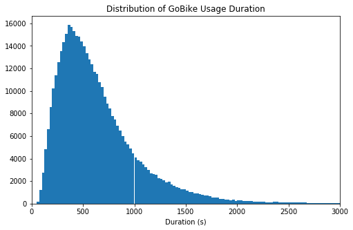

```python
binsize = 25
bins = np.arange(0, df_copy['duration_sec'].max()+binsize, binsize)

plt.figure(figsize=[8, 5])
plt.hist(data = df_copy, x = 'duration_sec', bins = bins)
plt.title('Distribution of GoBike Usage Duration')
plt.xlabel('Duration (s)')
plt.xlim(0, 3000)
plt.show()
```

## Distribution of GoBike Usage Distance

The distance travelled by the users are calculated from the coordinates of the start and end station. The formula used to calculate the distance is called Harvesine calculation

The usage distance has a unimodal distribution which is skewed to the right. Usage distance has a mode around 1 km. After the 2 km mark, the number of user that exceeds this distance drops rapidly.

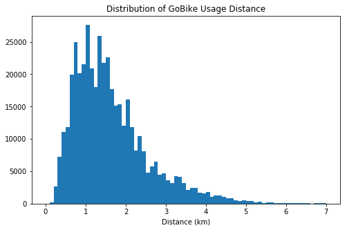

```python
binsize = 0.1
bins = np.arange(0, df_copy['distance_km'].max()+binsize, binsize)

plt.figure(figsize=[8, 5])
plt.hist(data = df_copy, x = 'distance_km', bins = bins)
plt.xlabel('Distance (km)')
plt.title('Distribution of GoBike Usage Distance')
plt.show()
```

## GoBike Usage Duration vs Distance

Plotting the duration and distance on a scatter plot enables us to see a positive correlation between usage distance and duration.

Logically, the users are able to travel further given a longer duration. Diving deeper into the plot, we see that usage duration affects the maximum distance travelled. From the plot, we can calculate the average distance travelled by users over a period of time. A rough estimates shows that users are able to travle 4.2 km in 1,000 sec. That is approximately 15 km/hr, a reasonable speed cycling speed.

The majority of the usage duration seemed to be below 2,000 sec, approximately 30 mins. This indicates a user behaviour, whereby users are less likely to use GoBike if the journey is expected to take more than 30 mins.

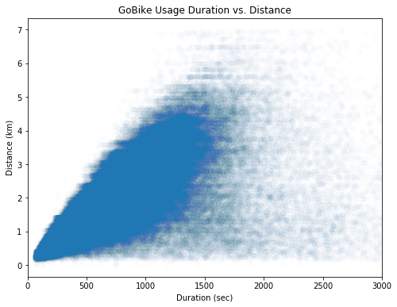

```python
plt.figure(figsize = [8, 6])
plt.scatter(data = df_copy, x = 'duration_sec', y = 'distance_km', alpha = 1/75)
plt.xlabel('Duration (sec)')
plt.ylabel('Distance (km)')
plt.xlim(0, 3000)
plt.title('GoBike Usage Duration vs. Distance')
plt.show()
```

## GoBike's User Demographic

Plotting the user information allows us to observe the distribution of GoBike's user demographic.

We expect the GoBike's user demographic to have an impact on its user behaviour.

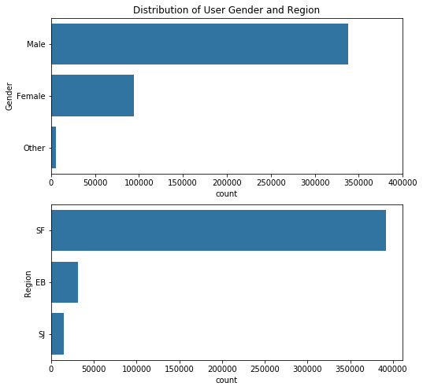

```python
plt.figure(figsize = [8, 8])

base_color = sb.color_palette()[0]

# subplot 1:
plt.subplot(2, 1, 1)
sb.countplot(data = df_copy, y = 'member_gender', color=base_color)
plt.xlim(0, 400000)
plt.ylabel('Gender')
plt.title('Distribution of User Gender and Region')

# subplot 2:
ax = plt.subplot(2, 1, 2)
sb.countplot(data = df_copy, y = 'region', color=base_color)
plt.ylabel('Region')

plt.show()
```

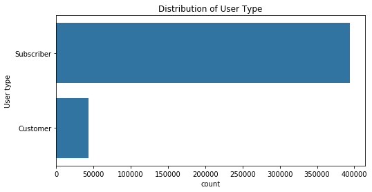

```python
plt.figure(figsize = [8, 4])

base_color = sb.color_palette()[0]

sb.countplot(data = df_copy, y = 'user_type', color=base_color)
plt.ylabel('User type')
plt.title('Distribution of User Type')

plt.show()
```

## User Demographic (Age)

There is a wide range in terms of GoBike's user age. Looking at the user age distribution, we see that the majority of the users are the age of 25-40. There is a minimum age for the GoBike user, which is the legal age of 18, to be able to use GoBike's services.

The age distribution is heavily skewed to the right, indicating GoBike has more young and working users in its user base.

Looking at the distribution of user type across ages, we see that younger users tends to be a customer. This is apparent in the age group below 25. Older users are more likely to be a subscriber, adopting a monthly membership plan.

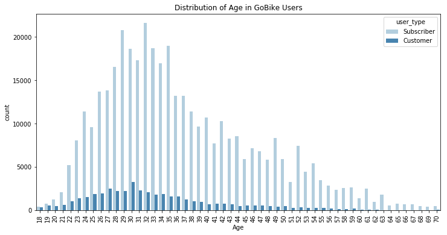

```python
# count plot of member_birth_year
plt.figure(figsize=[12,6])

sb.countplot(data = df_copy, x = 'member_age', hue = 'user_type', palette='Blues')
plt.xticks(rotation=90)
plt.title('Distribution of Age in GoBike Users')
plt.xlabel('Age')
plt.show()
```

## Time Series Plot of GoBike Users

Plotting the distribution of users and the type of users on a time series plot allows us to see the user's behaviour at different times.

Looking at the distribution of users in different days of the week, we see that the number of user that uses GoBike on the weekend is approximately 50% of that in weekday. Users tend to use GoBike more during the weekdays. This trend however, is only applicable for subscribers and not to the customers.

In a day, the usage of GoBike is the highest during the peak hours, betweem 8am - 9am and between 5pm - 6pm.

From both the time series plot, we found that subscribers tend to use GoBike before and after working hours to commute, in the weekdays. As for customers, the number of GoBike users are fairly consistent throughout the day as well as throughout the week.

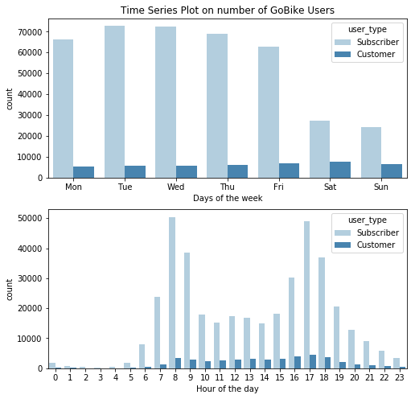

```python
plt.figure(figsize = [8, 8])

# subplot 1:
ax = plt.subplot(2, 1, 1)
sb.countplot(data = df_copy, x = 'week_day', hue = 'user_type', palette = 'Blues')
plt.xticks(ticks= np.arange(0, 7, 1),
           labels=['Mon', 'Tue', 'Wed', 'Thu', 'Fri', 'Sat', 'Sun'])
plt.xlabel('Days of the week')
plt.title('Time Series Plot on number of GoBike Users')

# subplot 2:
plt.subplot(2, 1, 2)
sb.countplot(data = df_copy, x = 'hour', hue = 'user_type', palette = 'Blues')
plt.xlabel('Hour of the day')

plt.show()
```

## Usage Duration by User Type for Selected User Age

A point plot is used to illustrate the differences between user behaviour of customer and subscriber in terms of usage duration across the age of 25-45.

For this particular age group, customers tend to use GoBike for longer durations, as compared to subscribers, which are mostly focused in shorter duration. The lower spread in terms of duration of use in the subscriber behaviour indicates that subscribers are looking for a consistent experience (eg. daily commute). This is contransting as compared to a customer which uses GoBike for exploration purposes, and hence a larger spread on the point plot.

Looking at the point plot, user age does not seemed to have an impact on the duration of use. Duration of use depends more on the end destination of the user instead.

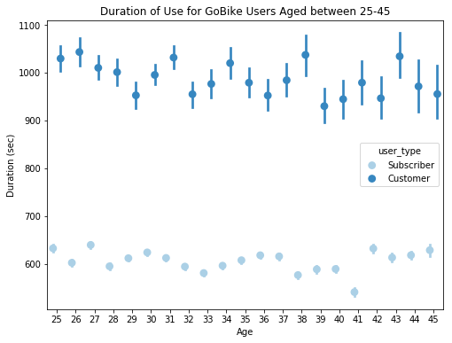

```python
# setting the figure size
fig = plt.figure(figsize = [8,6])
# point plot of age against duration with user_type
ax = sb.pointplot(data = df_plot, x = 'member_age', y = 'duration_sec', hue = 'user_type',
                  palette = 'Blues', linestyles = '', dodge = 0.4)
plt.title('Duration of Use for GoBike Users Aged between 25-45')
plt.ylabel('Duration (sec)')
plt.xlabel('Age')
ax.set_yticklabels([],minor = True)
plt.show();
```

## Usage Duration by User Region across the Week

Previously, we found that GoBike users, especially the subscribers, tends to use GoBike less during the weekends. Looking at the point plot, we see that GoBike usage durations is significantly higher in the weekends. This is true across all regions in the Bay Area, namely San Francisco, East Bay and San Jose. The spike in usage duration over the weekend indicates that GoBike users tend to use use GoBike longer for non-commute transport purposes.

Looking at the user behavior for each region, we find that users in San Francisco has the highest GoBike usage durations, followed by users in East Bay and San Jose. This indicates GoBike has better user adapotion in San Francisco. This is reasonable as San Francisco has the most GoBike facilities (bike docking stations), as compared to San Jose which has relatively the least facilities.

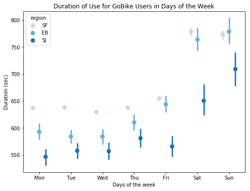

```python
fig = plt.figure(figsize = [8,6])
ax = sb.pointplot(data = df_copy, x = 'week_day', y = 'duration_sec', hue = 'region',
                  palette = 'Blues', linestyles = '', dodge = 0.4)
plt.title('Duration of Use for GoBike Users in Days of the Week')
plt.ylabel('Duration (sec)')
plt.xlabel('Days of the week')
plt.xticks(ticks= np.arange(0, 7, 1),
           labels=['Mon', 'Tue', 'Wed', 'Thu', 'Fri', 'Sat', 'Sun'])
ax.set_yticklabels([],minor = True)
plt.show();
```